# Análisis Multivariante - Ejercicios 1.1

Alejandro Keymer

```r
# cargo los datos del libro y las funciones
# cargo las bibliotecas que utilizo
source('https://www.york.ac.uk/depts/maths/data/everitt/chap1huswif.dat')
source('https://www.york.ac.uk/depts/maths/data/everitt/chiplot.r')
pacman::p_load(MASS, tidyverse, ggExtra, scatterplot3d, aplpack, broom, scatterplot3d)
```

# 1. Estadísticos

#### 1. Para la base de datos crabs del paquete MASS de R:

1. Estudiar la base de datos con la ayuda y las funciones str() y summary().

```r
# a)

str(crabs)
```

```
## 'data.frame':    200 obs. of  8 variables:
##  $ sp   : Factor w/ 2 levels "B","O": 1 1 1 1 1 1 1 1 1 1 ...
##  $ sex  : Factor w/ 2 levels "F","M": 2 2 2 2 2 2 2 2 2 2 ...
##  $ index: int  1 2 3 4 5 6 7 8 9 10 ...
##  $ FL   : num  8.1 8.8 9.2 9.6 9.8 10.8 11.1 11.6 11.8 11.8 ...
##  $ RW   : num  6.7 7.7 7.8 7.9 8 9 9.9 9.1 9.6 10.5 ...
##  $ CL   : num  16.1 18.1 19 20.1 20.3 23 23.8 24.5 24.2 25.2 ...
##  $ CW   : num  19 20.8 22.4 23.1 23 26.5 27.1 28.4 27.8 29.3 ...
##  $ BD   : num  7 7.4 7.7 8.2 8.2 9.8 9.8 10.4 9.7 10.3 ...
```

```r
summary(crabs)
```

```
##  sp      sex         index            FL              RW
##  B:100   F:100   Min.   : 1.0   Min.   : 7.20   Min.   : 6.50
##  O:100   M:100   1st Qu.:13.0   1st Qu.:12.90   1st Qu.:11.00
##                  Median :25.5   Median :15.55   Median :12.80
##                  Mean   :25.5   Mean   :15.58   Mean   :12.74
##                  3rd Qu.:38.0   3rd Qu.:18.05   3rd Qu.:14.30
##                  Max.   :50.0   Max.   :23.10   Max.   :20.20
##        CL              CW              BD
##  Min.   :14.70   Min.   :17.10   Min.   : 6.10
##  1st Qu.:27.27   1st Qu.:31.50   1st Qu.:11.40
##  Median :32.10   Median :36.80   Median :13.90
##  Mean   :32.11   Mean   :36.41   Mean   :14.03
##  3rd Qu.:37.23   3rd Qu.:42.00   3rd Qu.:16.60
##  Max.   :47.60   Max.   :54.60   Max.   :21.60
```

2. Calcular estadísticos descriptivos como la media, la mediana, la varianza, etc. de las variables numéricas, tanto para todos los datos, como para las especies y los sexos por separado.

```r
# b)
# creo una función para el cálculo de los estadísticos
summ <- function(df) {
    df %>%
        summarise(
            p25 = quantile(value, probs = 0.25),
            mean = mean(value),
            median = median(value),
            p75 = quantile(value, probs = 0.75),
            sd = sd(value),
            var = var(value)
        )
}

db <-
    crabs %>%
    select(-index) %>%
    gather(key, value, -sp, -sex)

# Estadísticas de todos los datos
db %>%
    group_by(key) %>%
    summ()
```

```
## # A tibble: 5 x 7
##   key     p25  mean median   p75    sd   var
##   <chr> <dbl> <dbl>  <dbl> <dbl> <dbl> <dbl>
## 1 BD     11.4  14.0   13.9  16.6  3.42 11.7
## 2 CL     27.3  32.1   32.1  37.2  7.12 50.7
## 3 CW     31.5  36.4   36.8  42    7.87 62.0
## 4 FL     12.9  15.6   15.6  18.0  3.50 12.2
## 5 RW     11    12.7   12.8  14.3  2.57  6.62
```

```r
# Estadísticos por especie
db %>%
    group_by(sp, key) %>%
    summ()
```

```
## # A tibble: 10 x 8
## # Groups:   sp [2]
##    sp    key     p25  mean median   p75    sd   var
##    <fct> <chr> <dbl> <dbl>  <dbl> <dbl> <dbl> <dbl>
##  1 B     BD     10.4  12.6   12.6  14.9  3.07  9.41
##  2 B     CL     24.8  30.1   30.1  34.6  6.90 47.6
##  3 B     CW     29.1  34.7   35.2  40.3  7.87 61.9
##  4 B     FL     11.8  14.1   14.4  16.1  3.02  9.12
##  5 B     RW     10.6  11.9   12    13.5  2.28  5.20
##  6 O     BD     13.3  15.5   15.6  17.8  3.15  9.93
##  7 O     CL     29.2  34.2   34.6  39.4  6.76 45.8
##  8 O     CW     32.3  38.1   39.0  43.7  7.54 56.9
##  9 O     FL     14.5  17.1   17.5  19.5  3.28 10.7
## 10 O     RW     11.5  13.5   13.6  15.6  2.61  6.79
```

```r
# Estadísticos por sexo
db %>%
    group_by(sex, key) %>%
    summ()
```

```
## # A tibble: 10 x 8
## # Groups:   sex [2]
##    sex   key     p25  mean median   p75    sd   var
##    <fct> <chr> <dbl> <dbl>  <dbl> <dbl> <dbl> <dbl>
##  1 F     BD     11.3  13.7   13.8  16.0  3.34 11.2
##  2 F     CL     26.6  31.4   31.7  35.9  6.70 44.9
##  3 F     CW     31.2  35.8   36.4  40.8  7.38 54.5
##  4 F     FL     12.8  15.4   15.4  18.1  3.54 12.5
##  5 F     RW     11.5  13.5   13.8  15.6  2.74  7.51
##  6 M     BD     11.8  14.3   14.2  16.8  3.49 12.2
##  7 M     CL     27.6  32.9   32.4  37.9  7.47 55.8
##  8 M     CW     31.6  37.0   37.1  42.8  8.33 69.4
##  9 M     FL     13.2  15.7   15.7  18.0  3.46 12.0
## 10 M     RW     10.7  12.0   11.9  13.5  2.16  4.67
```

3. Hallar los cinco números descriptivos de cada variable numérica. Utilizar la función fivenum().

```r
# c)
crabs %>%
    select(FL:BD) %>%
    map_df(~ fivenum(.x)) %>%
    rowid_to_column(var = "fivenum")
```

```
## # A tibble: 5 x 6
##   fivenum    FL    RW    CL    CW    BD
##     <int> <dbl> <dbl> <dbl> <dbl> <dbl>
## 1       1   7.2   6.5  14.7  17.1   6.1
## 2       2  12.9  11    27.2  31.5  11.4
## 3       3  15.6  12.8  32.1  36.8  13.9
## 4       4  18.1  14.3  37.2  42    16.6
## 5       5  23.1  20.2  47.6  54.6  21.6
```

4. Hallar las matrices de varianzas y covarianzas de las variables numéricas según especie y sexo.

```r
# d)
# cov para sexo masculino
crabs %>%
    filter(sex == "M") %>%
    select(FL:BD) %>%
    cov()
```

```
##           FL        RW       CL       CW       BD
## FL 11.994994  7.244283 25.45926 27.85104 12.02317
## RW  7.244283  4.667778 15.87688 17.61999  7.29704
## CL 25.459259 15.876879 55.81889 61.90702 25.58304
## CW 27.851044 17.619990 61.90702 69.39303 27.94377
## BD 12.023174  7.297040 25.58304 27.94377 12.20963
```

```r
# cov para sexo femenino
crabs %>%
    filter(sex == "F") %>%
    select(FL:BD) %>%
    cov()
```

```
##           FL        RW       CL       CW        BD
## FL 12.516945  9.382541 23.27271 25.34044 11.647911
## RW  9.382541  7.511445 18.12493 19.92736  8.918901
## CL 23.272707 18.124929 44.93010 49.29869 22.140263
## CW 25.340444 19.927364 49.29869 54.47808 24.141596
## BD 11.647911  8.918901 22.14026 24.14160 11.177196
```

```r
# cov para especie Orange
(cov_spO <-
    crabs %>%
    filter(sp == "O") %>%
    select(FL:BD) %>%
    cov())
```

```
##           FL        RW       CL       CW        BD
## FL 10.729394  7.718697 21.90159 24.49089 10.140828
## RW  7.718697  6.788787 15.41899 17.67314  7.059574
## CL 21.901586 15.418993 45.75524 50.84400 21.192592
## CW 24.490889 17.673143 50.84400 56.86551 23.530772
## BD 10.140828  7.059574 21.19259 23.53077  9.931834
```

```r
# cov para especie Azul
(cov_spB <-
crabs %>%
    filter(sp == "B") %>%
    select(FL:BD) %>%
    cov())
```

```
##           FL        RW       CL       CW        BD
## FL  9.118044  6.179527 20.74157 23.64237  9.158436
## RW  6.179527  5.195168 14.10301 16.21093  6.322804
## CL 20.741568 14.103006 47.64731 54.22052 21.004935
## CW 23.642372 16.210933 54.22052 61.87456 23.952615
## BD  9.158436  6.322804 21.00494 23.95262  9.411930
```

5. Comparar cada especie con medidas globales de variabilidad: varianza total tr(S), varianza media tr(S)/p, varianza generalizada |S| y varianza efectiva |S| 1/p.

```r
# e)
covs <- list("Orange" = cov_spO, "Blue" = cov_spB)

# en este caso hay 100 y 100 de cada especie
p <- length(crabs) / 2

## varianza total tr(S)
map(covs, function(x) sum(diag(x)))
```

```
## $Orange
## [1] 130.0708
##
## $Blue
## [1] 133.247
```

```r
## varianza media tr(S)/p
map(covs, function(x) sum(diag(x)) / p)
```

```
## $Orange
## [1] 32.51769
##
## $Blue
## [1] 33.31175
```

```r
## varianza generalizada
map(covs, det)
```

```
## $Orange
## [1] 0.2457478
##
## $Blue
## [1] 0.07706116
```

```r
## varianza efectiva
map(covs, function(x) det(x)^1/p)
```

```
## $Orange
## [1] 0.06143694
##
## $Blue
## [1] 0.01926529
```

#### 2. (∗) Para la base de datos huswif del libro de Everitt(2005)2

#### 3. (∗) Para la base de datos airpoll del libro de Everitt(2005).

#### 4. Entre los 10 elementos muestrales o parejas casadas (con papeles o no) de la base de datos huswif del libro de Everitt(2005):

1. Calcular las distancias euclídeas con la función dist de R y expresarlas en forma de matriz.

```r
# a)
huswif %>%
    dist() %>%
    as.matrix()
```

```
##            1         2         3         4        5         6         7
## 1    0.00000  52.54522 154.33405  60.04998 257.5578 135.81237  82.59540
## 2   52.54522   0.00000 193.16832  76.57023 268.3487 177.14965 126.16259
## 3  154.33405 193.16832   0.00000 147.70579 206.6906  56.51548  75.22633
## 4   60.04998  76.57023 147.70579   0.00000 202.5981 150.88075  86.34813
## 5  257.55776 268.34865 206.69059 202.59812   0.0000 255.32528 222.10358
## 6  135.81237 177.14965  56.51548 150.88075 255.3253   0.00000  67.60917
## 7   82.59540 126.16259  75.22633  86.34813 222.1036  67.60917   0.00000
## 8   69.75672 106.57861  92.32010  57.81003 202.9631  94.41928  33.85262
## 9  128.45622 164.15237  32.40370 123.82649 206.0267  51.24451  55.30823
## 10  79.58015 110.28146  84.39194  78.39005 211.8089  80.87027  39.28104
##            8         9        10
## 1   69.75672 128.45622  79.58015
## 2  106.57861 164.15237 110.28146
## 3   92.32010  32.40370  84.39194
## 4   57.81003 123.82649  78.39005
## 5  202.96305 206.02670 211.80888
## 6   94.41928  51.24451  80.87027
## 7   33.85262  55.30823  39.28104
## 8    0.00000  67.68309  29.98333
## 9   67.68309   0.00000  54.20332
## 10  29.98333  54.20332   0.00000
```

2. Calcular las distancias de K.Pearson y dar la matriz de distancias.

```r
# b)
## 1 - sum(x_i y_i) / sqrt [sum(x_i^2) sum(y_i^2)]
amap::Dist(huswif, method = "pearson", diag = T, upper = T)
```

```
##               1            2            3            4            5
## 1  0.000000e+00 2.360394e-04 1.408914e-03 5.044461e-05 4.809729e-05
## 2  2.360394e-04 0.000000e+00 2.546600e-03 2.089937e-04 3.960626e-04
## 3  1.408914e-03 2.546600e-03 0.000000e+00 1.886849e-03 1.493279e-03
## 4  5.044461e-05 2.089937e-04 1.886849e-03 0.000000e+00 4.344052e-05
## 5  4.809729e-05 3.960626e-04 1.493279e-03 4.344052e-05 0.000000e+00
## 6  1.496531e-03 2.596798e-03 3.172882e-05 2.006488e-03 1.639553e-03
## 7  4.210278e-04 1.184467e-03 3.326292e-04 6.605554e-04 4.478864e-04
## 8  1.312739e-04 6.609899e-04 6.891568e-04 3.010098e-04 1.784725e-04
## 9  9.208775e-04 1.790772e-03 8.514701e-05 1.347121e-03 1.068088e-03
## 10 2.848340e-04 7.570066e-04 5.455079e-04 5.544069e-04 4.446649e-04
##               6            7            8            9           10
## 1  1.496531e-03 4.210278e-04 1.312739e-04 9.208775e-04 2.848340e-04
## 2  2.596798e-03 1.184467e-03 6.609899e-04 1.790772e-03 7.570066e-04
## 3  3.172882e-05 3.326292e-04 6.891568e-04 8.514701e-05 5.455079e-04
## 4  2.006488e-03 6.605554e-04 3.010098e-04 1.347121e-03 5.544069e-04
## 5  1.639553e-03 4.478864e-04 1.784725e-04 1.068088e-03 4.446649e-04
## 6  0.000000e+00 4.009063e-04 7.569793e-04 7.816102e-05 5.524604e-04
## 7  4.009063e-04 0.000000e+00 8.756561e-05 1.758898e-04 1.283389e-04
## 8  7.569793e-04 8.756561e-05 0.000000e+00 3.801601e-04 8.068636e-05
## 9  7.816102e-05 1.758898e-04 3.801601e-04 0.000000e+00 2.205023e-04
## 10 5.524604e-04 1.283389e-04 8.068636e-05 2.205023e-04 0.000000e+00
```

3. Calcular la distancia de Mahalanobis (sin cuadrado) entre la primera y la última de las parejas (huswif[1,] y huswif[10,]).

```r
# c)
# ?? no entiendo como se puede hacer esto... que media se utiliza para centrar y que cov?
# Al utilizar la cov de los datos filtrados, me da error porque el sistema es singular

S <- try(solve(cov(huswif[c(1,10),])))
```

```
## Error in solve.default(cov(huswif[c(1, 10), ])) :
##   Lapack routine dgesv: system is exactly singular: U[2,2] = 0
```

```r
S_tot <- solve(cov(huswif))

# con la cov total:
as.matrix(huswif[1,] - huswif[10,]) %*% S_tot %*% t(as.matrix(huswif[1,] - huswif[10,]))
```

```
##          1
## 1 11.62147
```

4. Calcular las distancias al cuadrado de Mahalanobis de cada pareja al vector de medias y su correspondiente matriz de covarianzas. Probar ?mahalanobis en R.

```r
# d)
(huswif %>%
    mahalanobis(. , colMeans(.), cov(.)) -> hw_dis)
```

```
##        1        2        3        4        5        6        7        8
## 5.190305 5.933941 6.791552 2.834540 7.482253 5.400837 6.222828 1.150281
##        9       10
## 1.830916 2.162547
```

5. Realizar un qqplot entre los cuantiles de una distribución ji-cuadrado con 5 grados de libertad y las distancias al cuadrado de Mahalanobis. ¿Se ajustan? También se puede utilizar la función chisplot de Everitt.

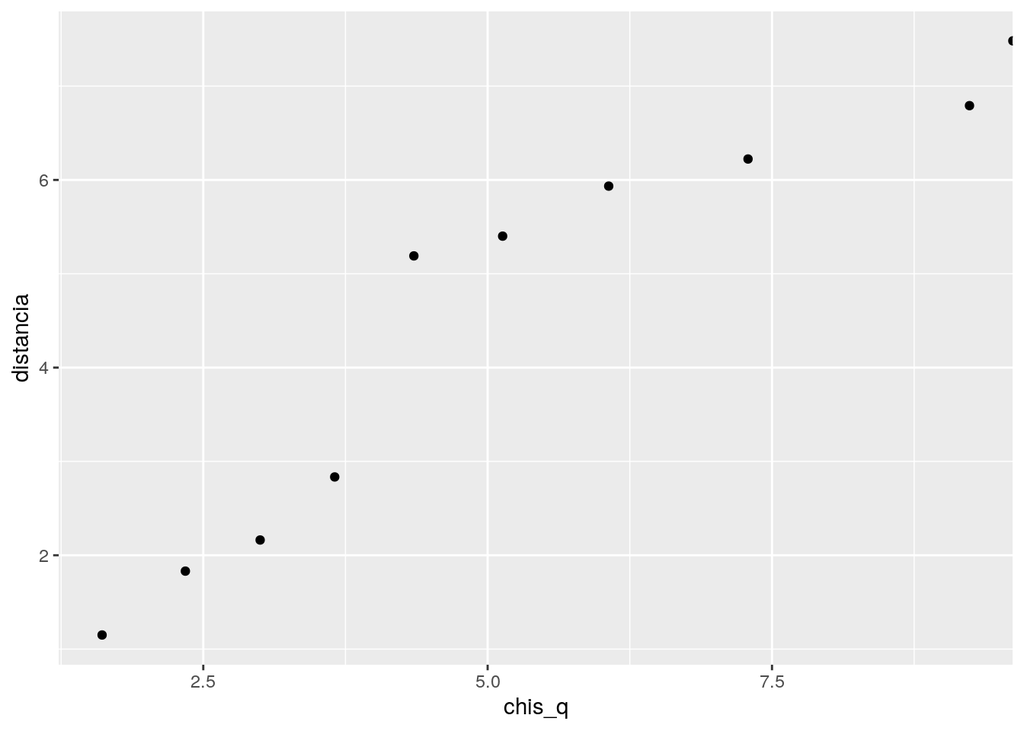

```r
# e) no estoy seguro de si entiendo lo que dice la pregunta, pero por lo que
# entiendo, el plot de un distribucion chi^2 con 5 DF y las distancias
# caluculadas, es lo que devuelve la funcion de chisplot.
# Mi version en ggplot

tibble(
  chis_q = qchisq(c((1:10)/10), 5),
  distancia = sort(hw_dis)
) %>%
  ggplot(aes(chis_q, distancia)) +
  geom_point()
```

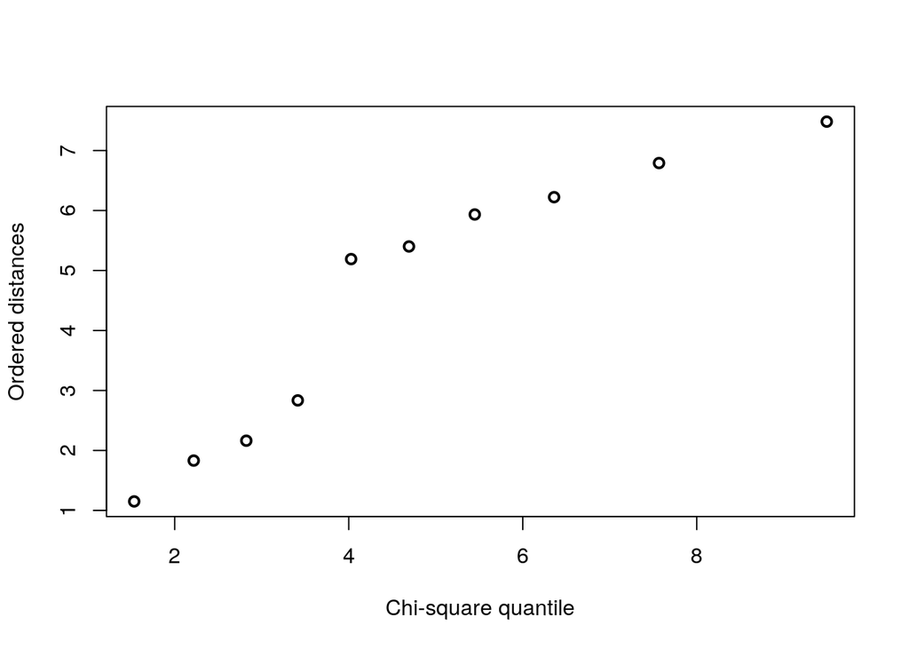

```r
chisplot(as.matrix(huswif))
```

#### 5. (∗) Estudiar el ajuste de las distancias al cuadrado de Mahalanobis para los datos de airpoll del

libro de Everitt a una distribución ji-cuadrado. Utilizar un qqplot o un chisplot de Everitt. También podemos utilizar el gráfico de la función outlier del paquete psych.

#### 6. Con la base de datos huswif del libro de Everitt(2005):

```r
# a)
```

#### 7. Comprobar que la desviación típica generalizada en el caso de dos variables es…

```r
# a)
crabs %>%
    filter(sp == "O",
           sex == "M") %>%
    select(CL, CW) %>%
    cor()
```

```
##           CL        CW
## CL 1.0000000 0.9989676
## CW 0.9989676 1.0000000
```

2. Hallar la correlación múltiple entre la variable BD y el resto.

```r
# b)
crabs %>%
    filter(sp == "O",
           sex == "M") %>%
    select(FL, RW, CL, CW, BD) %>%
    lm(data = ., BD ~ FL + RW + CL + CW) %>%
    tidy()
```

```
## # A tibble: 5 x 5
##   term        estimate std.error statistic p.value
##   <chr>          <dbl>     <dbl>     <dbl>   <dbl>
## 1 (Intercept)  -0.569      0.395    -1.44   0.157
## 2 FL            0.202      0.110     1.83   0.0732
## 3 RW            0.0308     0.126     0.246  0.807
## 4 CL            0.188      0.119     1.58   0.121
## 5 CW            0.156      0.105     1.48   0.145
```

3. El coeficiente de correlación parcial es una medida de dependencia directa entre dos variables.

# 2. Gráficos

#### 9. Con las variables CL y CW de la base de datos crabs del paquete MASS de R:

1. Crear el diagrama de dispersión de las dos variables y sus histogramas marginales.

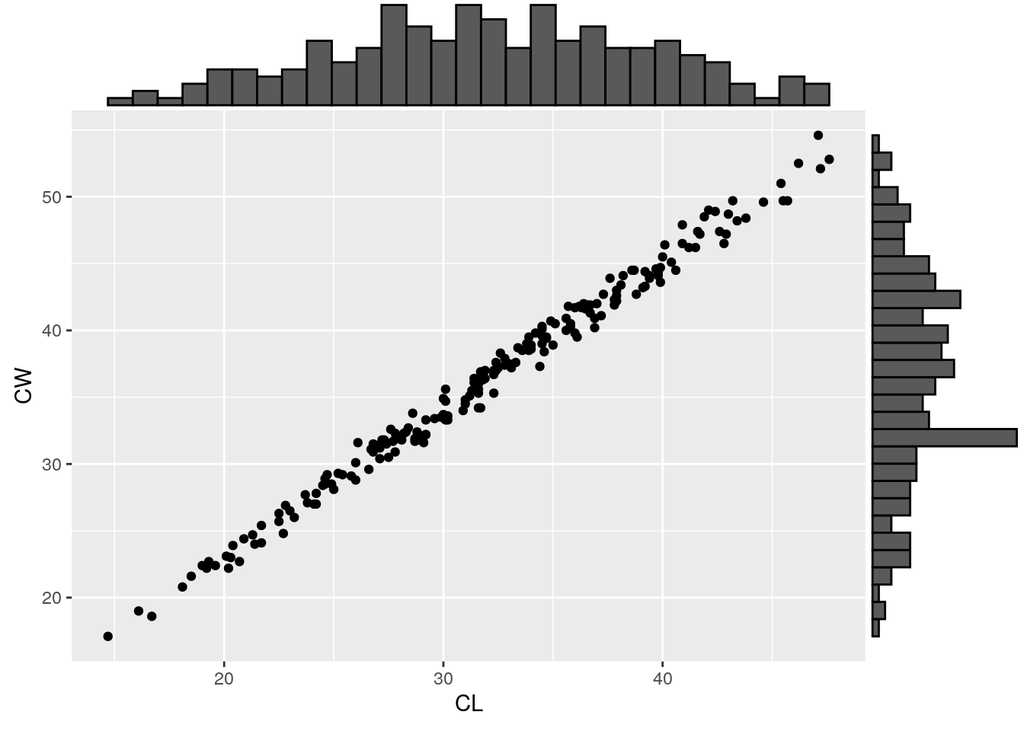

```r
p <- ggplot(data = crabs, aes(CL, CW)) + geom_point()

ggMarginal(p, type = "histogram")
```

2. Crear el diagrama de dispersión de las dos variables y sus diagramas de caja marginales.

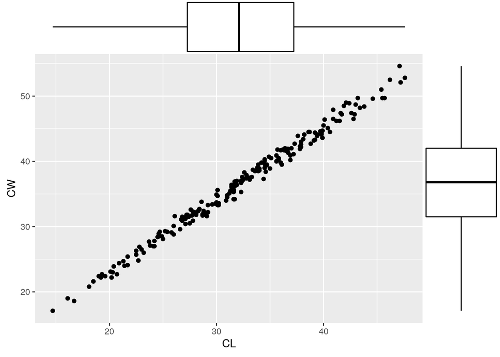

```r
ggMarginal(p, type = "box")
```

## 10. Con la base de datos crabs del paquete MASS de R, realizar los siguientes diagramas de caja múltiples:

1. Para comparar las variables según especie.

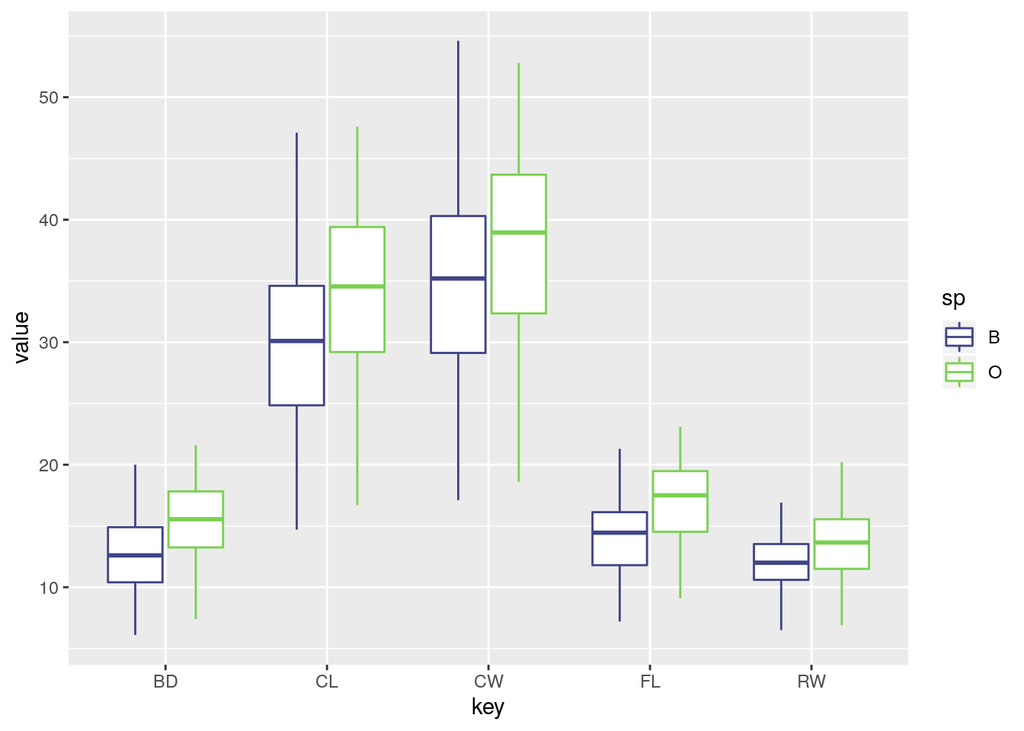

```r
# a)
crabs %>%
    gather(key, value, -sex, -sp, -index) %>%
    ggplot(aes(key, value, color = sp)) +
    geom_boxplot() +
    scale_color_viridis_d(begin = .2, end = .8)
```

2. Para comparar las variables según sexo.

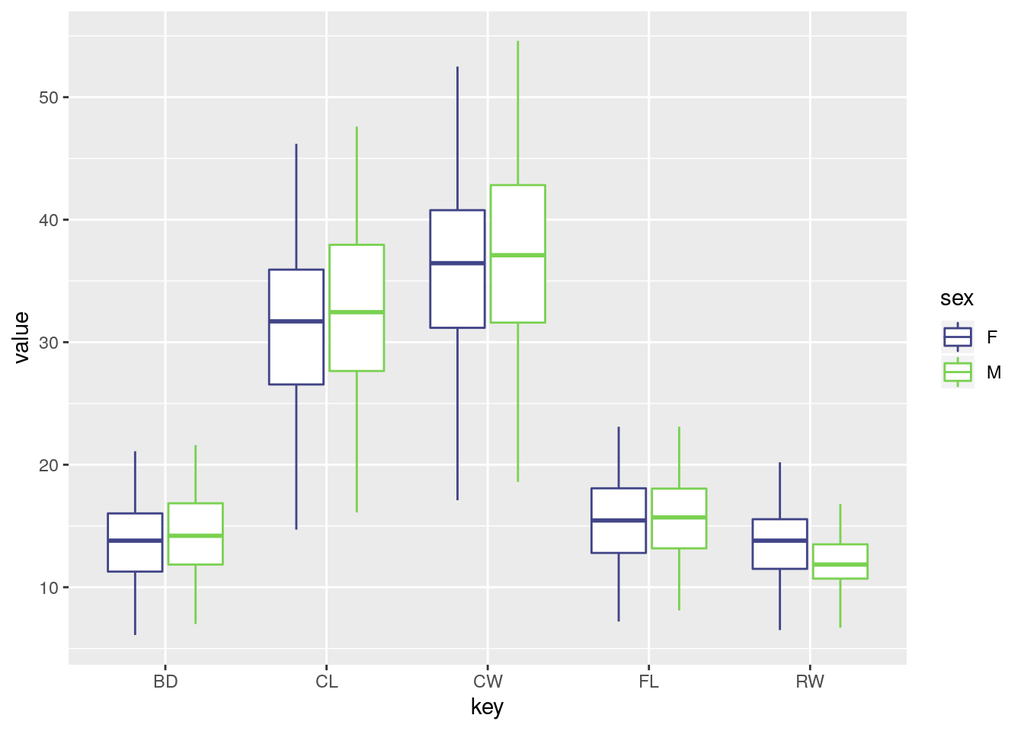

```r
# b)
crabs %>%
    gather(key, value, -sex, -sp, -index) %>%
    ggplot(aes(key, value, color = sex)) +
    geom_boxplot() +
    scale_color_viridis_d(begin = .2, end = .8)
```

3. Para comparar las variables según especie y sexo.

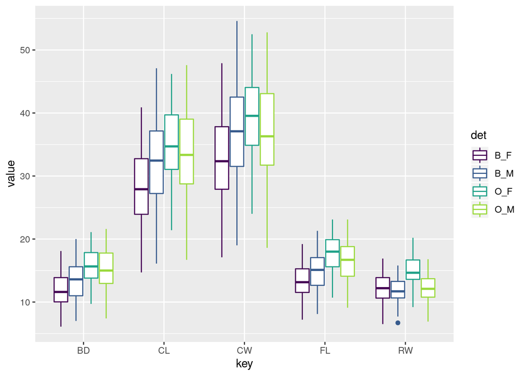

```r
# c)
crabs %>%
    gather(key, value, -sex, -sp, -index) %>%
    unite(det, sp, sex) %>%
    ggplot(aes(key, value, color = det)) +
    geom_boxplot() +
    scale_color_viridis_d(end = .85)
```

## 11. Con la base de datos crabs del paquete MASS de R, realizar un matriz de diagramas de dispersión según especie y sexo con la instrucción pairs().

1. Añadir los histogramas de cada variable a la diagonal.
2. Añadir la recta de regresión a cada diagrama de dispersión.

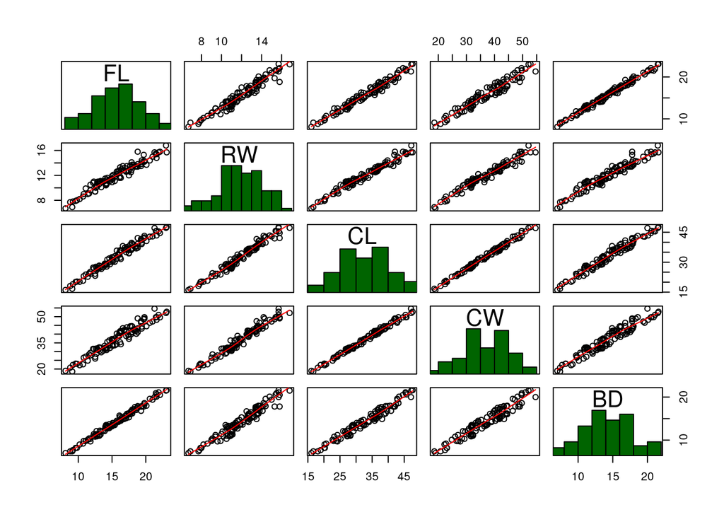

```r
panel.hist <- function(x, ...)
{
    usr <- par("usr"); on.exit(par(usr))
    par(usr = c(usr[1:2], 0, 1.5) )
    h <- hist(x, plot = FALSE)
    breaks <- h$breaks; nB <- length(breaks)
    y <- h$counts; y <- y/max(y)
    rect(breaks[-nB], 0, breaks[-1], y, col = "darkgreen", ...)
}

crabs %>%
    filter(sex == 'M') %>%
    select(4:8) %>%
    pairs(., panel = panel.smooth, diag.panel = panel.hist)
```

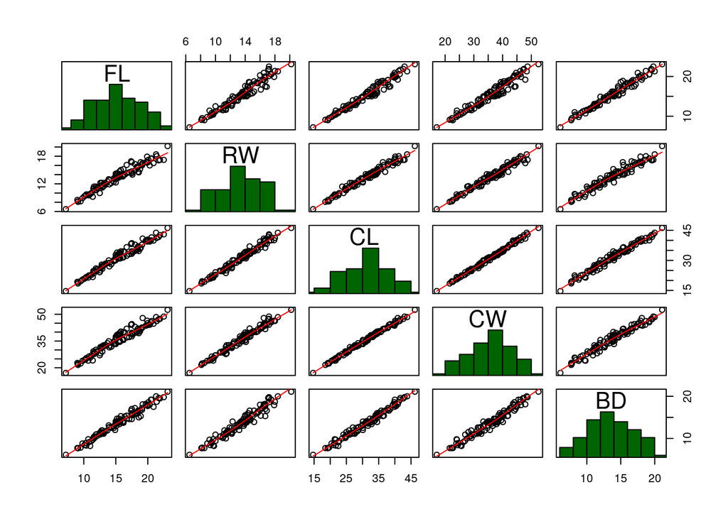

```r
crabs %>%
    filter(sex == 'F') %>%
    select(4:8) %>%
    pairs(., panel = panel.smooth, diag.panel = panel.hist)
```

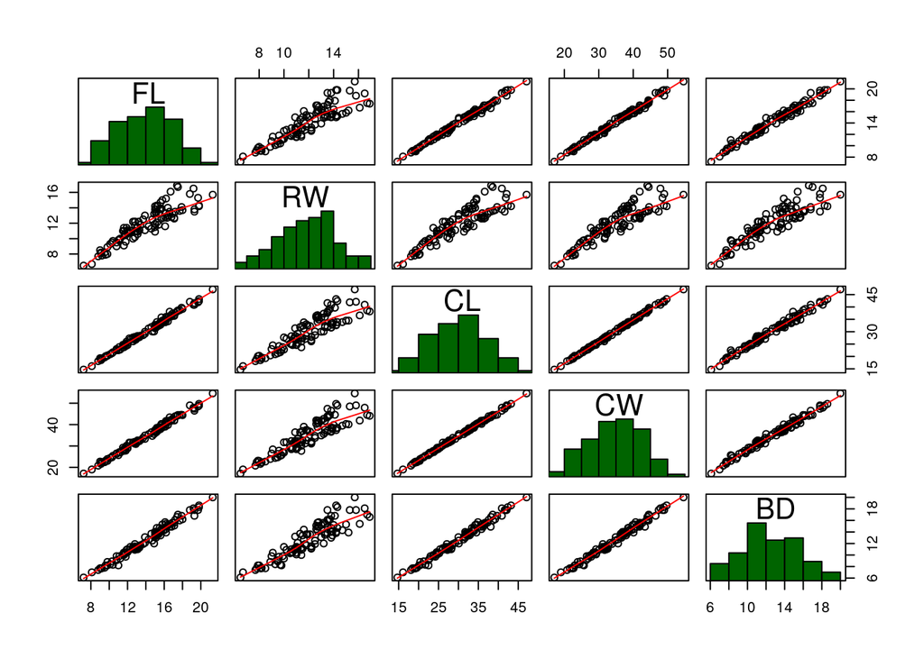

```r
crabs %>%
    filter(sp == 'B') %>%
    select(4:8) %>%
    pairs(., panel = panel.smooth, diag.panel = panel.hist)
```

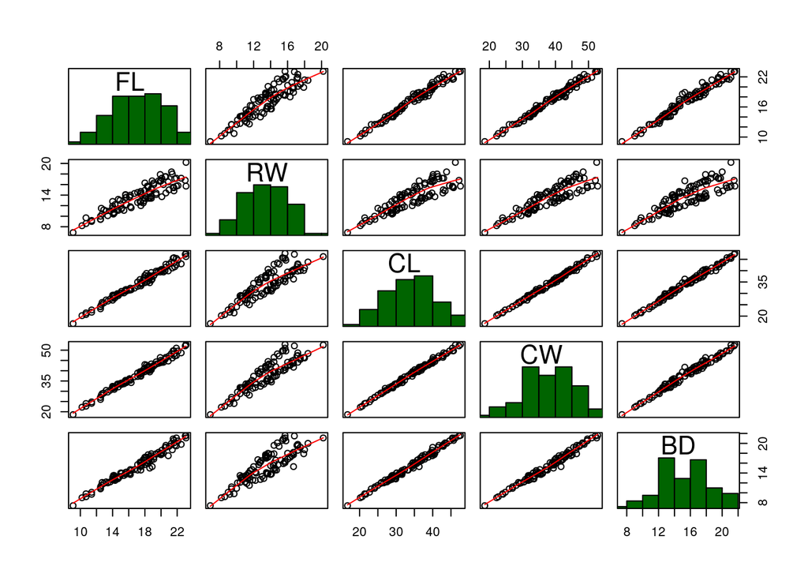

```r
crabs %>%
    filter(sp == 'O') %>%
    select(4:8) %>%
    pairs(., panel = panel.smooth, diag.panel = panel.hist)
```

## 12. Con la base de datos huswif del libro de Everitt(2005):

1. Calcular algún gráfico de dispersión 3D con la función scatterplot3d() del paquete scatterplot3d.

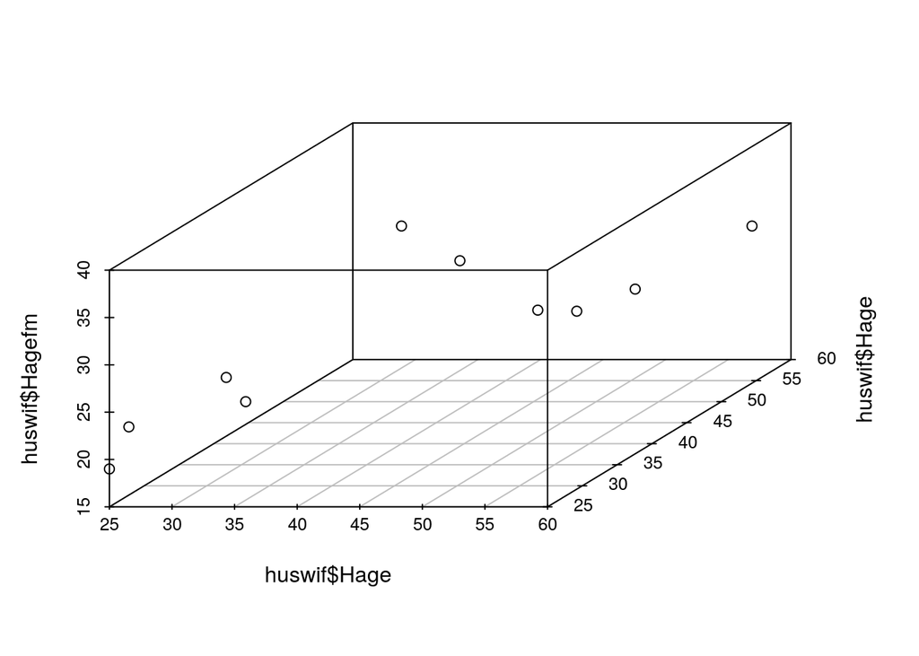

```r
# a)
scatterplot3d(huswif$Hage, huswif$Hage, huswif$Hagefm)
```

2. Realizar un gráfico de dispersión en dos dimensiones de las variables edad del marido y edad de la mujer. Añadir con la función symbols() la variable edad del marido en el primer matrimonio.

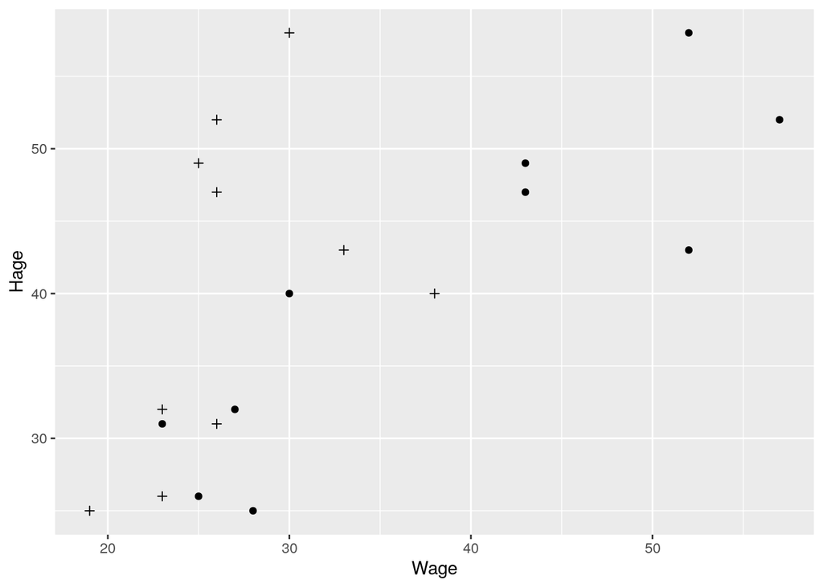

```r
# b)
huswif %>%
    ggplot(aes(Wage, Hage)) +
    geom_point() +
    geom_point(aes(x = Hagefm), shape = 3)
```

## 13. (*) Representar con caras de Chernoff las parejas de la base de datos huswif del libro de Everitt(2005).

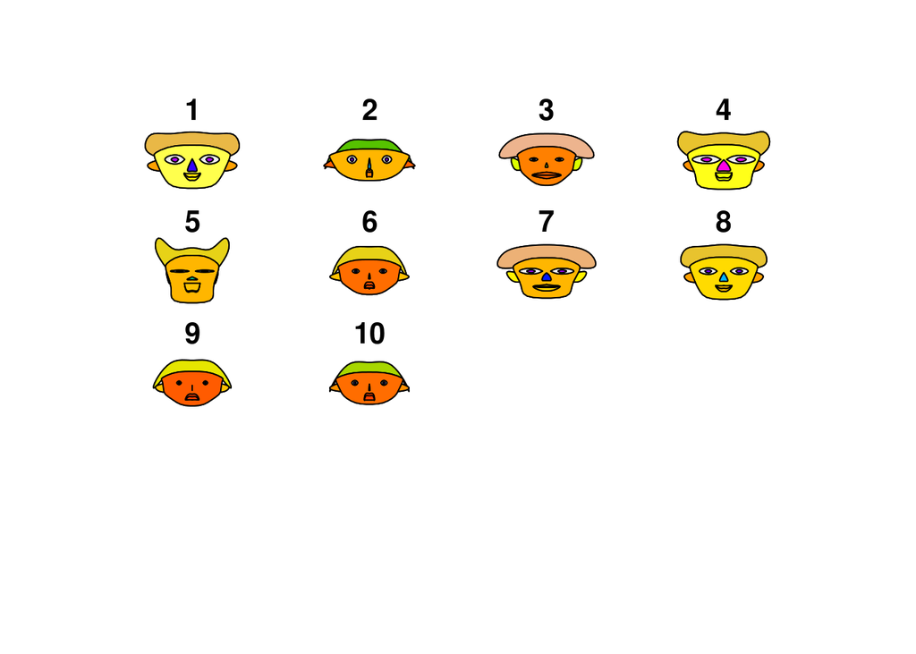

```
## effect of variables:
##  modified item       Var
##  "height of face   " "Hage"
##  "width of face    " "Hheight"
##  "structure of face" "Wage"
##  "height of mouth  " "Wheight"
##  "width of mouth   " "Hagefm"
##  "smiling          " "Hage"
##  "height of eyes   " "Hheight"
##  "width of eyes    " "Wage"
##  "height of hair   " "Wheight"
##  "width of hair   "  "Hagefm"
##  "style of hair   "  "Hage"
##  "height of nose  "  "Hheight"
##  "width of nose   "  "Wage"
##  "width of ear    "  "Wheight"
##  "height of ear   "  "Hagefm"
```

```r
faces(huswif)
```

## 14. (*) Representar con un gráfico de estrellas los vectores de medias de todas las variables numéricas de la base de datos crabs del paquete MASS de R en los cuatro grupos, según especie y sexo.4

```r
crabs %>%
    gather(key, value, -sex, -sp, -index) %>%
    group_by(sp, sex, key) %>%
    summarise(mean = mean(value)) %>%
    unite("cat", sex, sp) %>%
    spread(key, mean) -> st

st[,2:6]
```

```
## # A tibble: 4 x 5
##      BD    CL    CW    FL    RW
##   <dbl> <dbl> <dbl> <dbl> <dbl>
## 1  11.8  28.1  32.6  13.3  12.1
## 2  15.6  34.6  39.0  17.6  14.8
## 3  13.4  32.0  36.8  14.8  11.7
## 4  15.3  33.7  37.2  16.6  12.3
```

[figure not shown]

```r
stars(st[,2:6], key.loc = c(6,5))
```

```r
dt <-
crabs %>%
  filter(sex == "M",
         sp == "O") %>%
  select(FL:BD)

# a)
# los datos atipicos son:
# Creo que tengo bien la fórmula, pero no me sale
# ningun valor atípico que la satisfaga con  > 5.... ?!?!
dt %>%
  rowid_to_column() %>%
  gather(key, value, -rowid) %>%
  group_by(key) %>%
  filter(abs(value - median(value)) / mad(value, constant = 1) > 5) %>%
  spread(key, value)
```

```
## # A tibble: 0 x 1
## # … with 1 variable: rowid <int>
```

```r
# b)
# los datos atipicos son:
# Creo que tengo bien la fórmula, pero no me sale
# ningun valor atípico fuera de 1.5 IQR

dt %>%
  rowid_to_column() %>%
  gather(key, value,-rowid) %>%
  group_by(key) %>%
  filter(
    value > quantile(value, .75) + 1.5 * IQR(value) |
      value < quantile(value, 0.25) - 1.5 * IQR(value)
  ) %>%
  spread(key, value)
```

```
## # A tibble: 0 x 1
## # … with 1 variable: rowid <int>
```

3. Con un criterio multivariante sencillo como
1. Se busca el 50% de los datos con menor distancia de Mahalanobis al centro ¯x, media de todos los datos.

```r
# c) 1

S <- cov(dt)
X <- apply(dt, 2, mean)
X_tot <- mean(X)

# Me confude la noción  de 'media de todos los datos'. Me hace mas sentido
# calcular la distancia a la media de cada columna, que es lo que hago a
# continuación.

(new_dt <-
dt %>%
  bind_cols(maha = mahalanobis(dt, X, S)) %>%
  arrange(maha) %>%
  top_frac(.5, -maha))
```

```
##      FL   RW   CL   CW   BD      maha
## 1  18.6 13.4 37.8 41.9 17.3 0.6447104
## 2  15.1 11.5 30.9 34.0 13.9 0.7888665
## 3  14.2 10.6 28.7 31.7 12.9 1.3022771
## 4  14.7 11.1 29.0 32.1 13.1 1.3194529
## 5  16.2 11.8 32.3 35.3 14.7 1.4151855
## 6  14.2 10.7 27.8 30.9 12.7 1.4923457
## 7  15.1 11.4 30.2 33.3 14.0 1.6374680
## 8  13.4 10.1 26.6 29.6 12.0 1.6656597
## 9  17.1 12.6 35.0 38.9 15.7 1.7066290
## 10 18.8 13.8 39.2 43.3 17.9 1.7713220
## 11 17.4 12.8 36.1 39.5 16.2 1.9345071
## 12 19.4 14.1 39.1 43.2 17.8 2.1904330
## 13 21.0 15.0 42.9 47.2 19.4 2.5220972
## 14 17.5 12.7 34.6 38.4 16.1 2.8349319
## 15 14.1 10.7 28.7 31.9 13.3 2.9430979
## 16 11.4  9.0 22.7 24.8 10.1 2.9641804
## 17 17.9 12.9 36.9 40.9 16.5 3.0916457
## 18 12.5  9.4 24.2 27.0 11.2 3.3078484
## 19 10.7  8.6 20.7 22.7  9.2 3.4318375
## 20 17.8 12.5 36.0 39.8 16.7 3.4643985
## 21 15.4 11.1 30.2 33.6 13.5 3.7452395
## 22 10.2  8.2 20.2 22.2  9.0 4.0241899
## 23 14.2 11.3 29.2 32.2 13.5 4.0685435
## 24 19.4 14.4 39.8 44.3 17.9 4.1514778
## 25 18.4 13.4 37.9 42.2 17.7 4.2799920
```

```r
# en caso de que se utilice "la media de todos los datos" las distancias calculadas son muy grandes, y no comprendo su significado...

dt %>%
  bind_cols(maha = mahalanobis(dt, X_tot, S)) %>%
  arrange(maha) %>%
  top_frac(.5, -maha)
```

```
##      FL   RW   CL   CW   BD     maha
## 1  18.6 13.5 36.9 40.2 17.0 4639.334
## 2  18.8 13.4 37.2 41.1 17.5 4668.768
## 3  16.3 11.6 31.6 34.2 14.5 4724.415
## 4  15.7 12.2 31.7 34.2 14.2 4727.953
## 5  23.0 16.8 47.2 52.1 21.5 4752.922
## 6  17.5 12.7 34.6 38.4 16.1 4754.159
## 7  12.5  9.4 23.2 26.0 10.8 4771.793
## 8  22.1 15.8 44.6 49.6 20.5 4786.364
## 9  15.1 11.4 30.2 33.3 14.0 4791.693
## 10 12.7 10.4 26.0 28.8 12.1 4803.721
## 11 14.2 11.3 29.2 32.2 13.5 4807.300
## 12 19.4 14.1 39.1 43.2 17.8 4833.559
## 13 16.2 11.8 32.3 35.3 14.7 4865.743
## 14 14.2 10.7 27.8 30.9 12.7 4867.912
## 15 18.0 13.4 36.7 41.3 17.1 4876.300
## 16 14.7 11.1 29.0 32.1 13.1 4885.139
## 17 14.0 11.5 29.2 32.2 13.1 4898.433
## 18 13.7 11.0 27.5 30.5 12.2 4902.246
## 19 13.2 11.0 27.1 30.4 12.2 4910.727
## 20 18.4 13.4 37.9 42.2 17.7 4913.347
## 21 21.6 14.8 43.4 48.2 20.1 4914.501
## 22 12.5  9.4 24.2 27.0 11.2 4915.888
## 23 10.7  8.6 20.7 22.7  9.2 4923.953
## 24 21.0 15.0 42.9 47.2 19.4 4926.816
## 25 21.5 15.5 45.5 49.7 20.9 4943.067
```

```r
# c) 2
dt_r <- new_dt %>% select(-maha)
(S_r <- cov(dt))
```

```
##           FL        RW       CL       CW        BD
## FL 12.355024  7.598151 26.61889 29.31460 12.324465
## RW  7.598151  4.820771 16.53423 18.23423  7.647053
## CL 26.618890 16.534229 57.93047 63.77230 26.763355
## CW 29.314604 18.234229 63.77230 70.34842 29.488253
## BD 12.324465  7.647053 26.76336 29.48825 12.441045
```

```r
(X_r <- apply(dt_r, 2, mean))
```

```
##     FL     RW     CL     CW     BD
## 15.788 11.724 31.868 35.236 14.492
```

```r
(X_r_t <- mean(X_r))
```

```
## [1] 21.8216
```

3. Se calculan las distancias de Mahalanobis d2 M de todos los datos a la media x¯R con la matriz de covarianzas SR.

```r
# c) 3
mahalanobis(dt_r, X_r_t, S_r)
```

```
##  [1] 4405.739 4438.162 4514.791 4347.808 4329.053 4331.105 4258.760
##  [8] 4479.055 4534.470 4452.791 4498.678 4299.957 4388.134 4223.889
## [15] 4414.812 4449.705 4621.784 4375.432 4383.803 4426.313 4501.835
## [22] 4487.931 4273.678 4430.297 4373.485
```

```r
# c) 4
# esto creo que no lo he resuelto bien. Creo que el problema lo tengo al
# calcular la distancia a la media de todos los datos. No comprendo las
# magnitudes de las distancias que calculo
vars <- ncol(dt_r)

dt_r %>%
  mutate(maha = mahalanobis(.,X_r_t, S_r),
         test =  vars + (3 * sqrt(2 * vars)),
         atipico = maha > vars)
```

```
##      FL   RW   CL   CW   BD     maha     test atipico
## 1  18.6 13.4 37.8 41.9 17.3 4405.739 14.48683    TRUE
## 2  15.1 11.5 30.9 34.0 13.9 4438.162 14.48683    TRUE
## 3  14.2 10.6 28.7 31.7 12.9 4514.791 14.48683    TRUE
## 4  14.7 11.1 29.0 32.1 13.1 4347.808 14.48683    TRUE
## 5  16.2 11.8 32.3 35.3 14.7 4329.053 14.48683    TRUE
## 6  14.2 10.7 27.8 30.9 12.7 4331.105 14.48683    TRUE
## 7  15.1 11.4 30.2 33.3 14.0 4258.760 14.48683    TRUE
## 8  13.4 10.1 26.6 29.6 12.0 4479.055 14.48683    TRUE
## 9  17.1 12.6 35.0 38.9 15.7 4534.470 14.48683    TRUE
## 10 18.8 13.8 39.2 43.3 17.9 4452.791 14.48683    TRUE
## 11 17.4 12.8 36.1 39.5 16.2 4498.678 14.48683    TRUE
## 12 19.4 14.1 39.1 43.2 17.8 4299.957 14.48683    TRUE
## 13 21.0 15.0 42.9 47.2 19.4 4388.134 14.48683    TRUE
## 14 17.5 12.7 34.6 38.4 16.1 4223.889 14.48683    TRUE
## 15 14.1 10.7 28.7 31.9 13.3 4414.812 14.48683    TRUE
## 16 11.4  9.0 22.7 24.8 10.1 4449.705 14.48683    TRUE
## 17 17.9 12.9 36.9 40.9 16.5 4621.784 14.48683    TRUE
## 18 12.5  9.4 24.2 27.0 11.2 4375.432 14.48683    TRUE
## 19 10.7  8.6 20.7 22.7  9.2 4383.803 14.48683    TRUE
## 20 17.8 12.5 36.0 39.8 16.7 4426.313 14.48683    TRUE
## 21 15.4 11.1 30.2 33.6 13.5 4501.835 14.48683    TRUE
## 22 10.2  8.2 20.2 22.2  9.0 4487.931 14.48683    TRUE
## 23 14.2 11.3 29.2 32.2 13.5 4273.678 14.48683    TRUE
## 24 19.4 14.4 39.8 44.3 17.9 4430.297 14.48683    TRUE
## 25 18.4 13.4 37.9 42.2 17.7 4373.485 14.48683    TRUE
```

4. También podemos utilizar la distancia de Mahalanobis d2 M calculada con estimadores robustos como los que se obtienen con la función cov.rob del paquete MASS. Uno de los métodos más utilizados es el minimum covariance determinant o MCD que calcula los estimadores de centro y covarianza con un grupo de datos reducido, precisamente el que minimiza el determinante de la covarianza (una de las medidas de variabilidad multivariante). Con estas distancias robustas, podemos dibujar un gráfico para observar por inspección los puntos más extremos. Algunos autores sugieren como punto de corte la cola superior al 97.5 % de la distribución ji-cuadrado asociada a la distancia de Mahalanobis. Otro gráfico con estas distancias robustas es el ajuste a la distribución ji-cuadrado para observar los valores máximos.

```r
# d)
MASS::cov.rob(dt_r, method = "mcd")
```

```
## $center
##       FL       RW       CL       CW       BD
## 15.43684 11.50526 31.12105 34.39474 14.12105
##
## $cov
##           FL        RW       CL       CW        BD
## FL  9.414678  5.969795 20.30307 22.46020  9.325292
## RW  5.969795  3.799415 12.89655 14.25503  5.919883
## CL 20.303070 12.896550 44.04953 48.69012 20.181754
## CW 22.460205 14.255029 48.69012 53.85497 22.325117
## BD  9.325292  5.919883 20.18175 22.32512  9.283977
##
## $msg
## [1] "0 singular samples of size 6 out of 3000"
##
## $crit
## [1] -12.49138
##
## $best
##  [1]  1  2  3  4  6  7  8  9 12 14 16 17 18 19 22
##
## $n.obs
## [1] 25
```

#### 16. Realizar un boxplot bivariante con la funciónbvbox()de Everitt para las variables CL y CW dela base de datoscrabsdel paqueteMASSdeR.¿Cuales son las medidas de dispersión robustas que se utilizan en el gráfico?

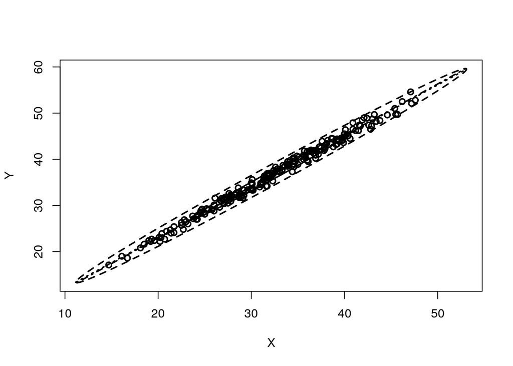

```r
#
url <- 'https://www.york.ac.uk/depts/maths/data/everitt/chiplot.r'
source(url)

crabs %>%
  select(CL,CW) %>%
  as.matrix() %>%
  bvbox(.)
```

#### 17.(∗)Un grupo muy importante de técnicas de representación de datos que no hemos explicado enlos documentos de esta asignatura son losgráficos en panel(trellis) que podemos hallar en elpaquetelatticedeR.Uno de los lugares donde informarse sobre los gráficos trellis es:http://www.stat.auckland.ac.nz/~ihaka/787/lectures-trellis.pdf. Escribir un breve informe (menos de una página) que describa las características de los gráficostrellis y discutir sus méritos.¿Qué hace diferentes a los gráficos trellis de otras técnicas de representación de datos multivariantes?¿Pueden ser útiles para ti? ¿Cuando crees que es mejor usar gráficos en trellis que otras técnicas?Mejor si se incluyen referencias a las fuentes.

Los gráficos que utilizan paneles o gráficos Trellis son particularmente utiles en análisis multivariante. La utilización de paneles permite abstrer una dimensión de los datos en los diferentes paneles y de esta froma se permite una visión mas clara de los datos. La utilización de paneles en combinación con otras técnicas de representación que pueden incluir el utilizar colores y fromas, permite la visualización de datos multivariables de una manera clara. A continuación presento un ejemplo en el que se grafica la misma información con una version con/sin paneles. fuente: http://www.cookbook-r.com/

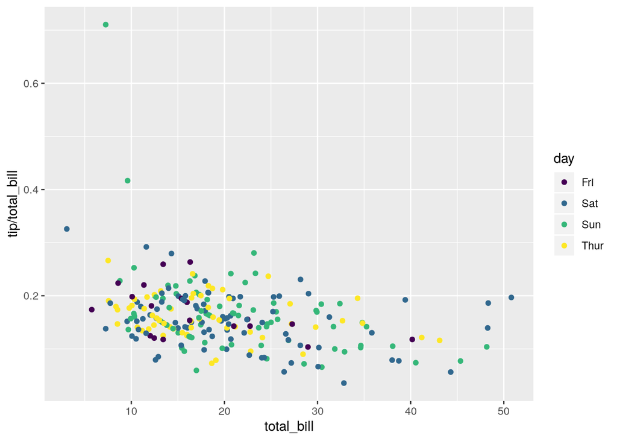

```r
reshape::tips %>%
  ggplot(aes(total_bill, tip/total_bill, color = day)) +
  geom_point() +
  scale_colour_viridis_d()
```

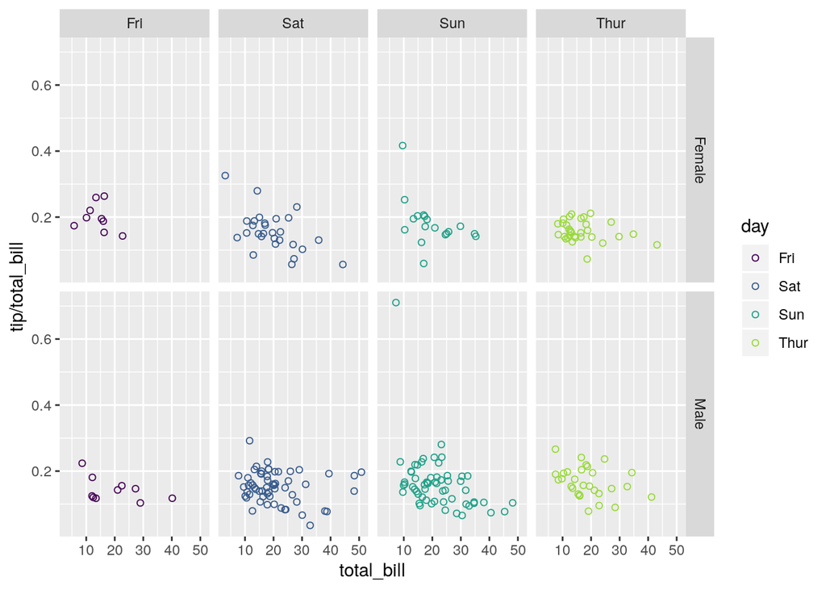

```r
reshape::tips %>%
  ggplot(aes(total_bill, tip/total_bill, color = day)) +
  geom_point(shape = 1) +
  scale_colour_viridis_d(end = .85) +
  facet_grid(sex ~ day)
```

#### 18.(∗)El paqueteggplot2, creado por Hadley Wickham, ofrece un poderoso lenguaje gráfico paracrear gráficos elegantes y complejos. Su popularidad en la comunidad R ha explotado en los últimosaños. Originalmente basado en la gramática de los gráficos de Leland Wilkinson,ggplot2permitecrear gráficos que representan datos numéricos y categóricos univariantes y multivariantes de maneradirecta. La agrupación se puede representar por color, símbolo, tamaño y transparencia. La creaciónde gráficos en panel (es decir, con condiciones) es relativamente simple. Repetir el ejercicio 10 con los gráficos del paqueteggplot2